# Didattica Integrativa

2022-04-29

# Regressione Lineare

In questa lezione abbiamo ripreso i punti fondamentali della regressione lineare semplice e multipla. Una volta chiari questi aspetti fondamentali tutte le applicazioni più avanzate non sono altro che estensioni del modello di base.

Simuliamo dei dati (senza associazione lineare)

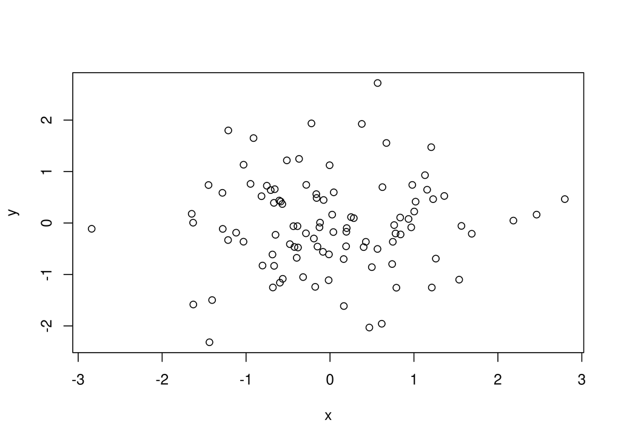

```r
y <- rnorm(100, mean = 0, sd = 1)
x <- rnorm(100, mean = 0, sd = 1)
plot(x, y)
```

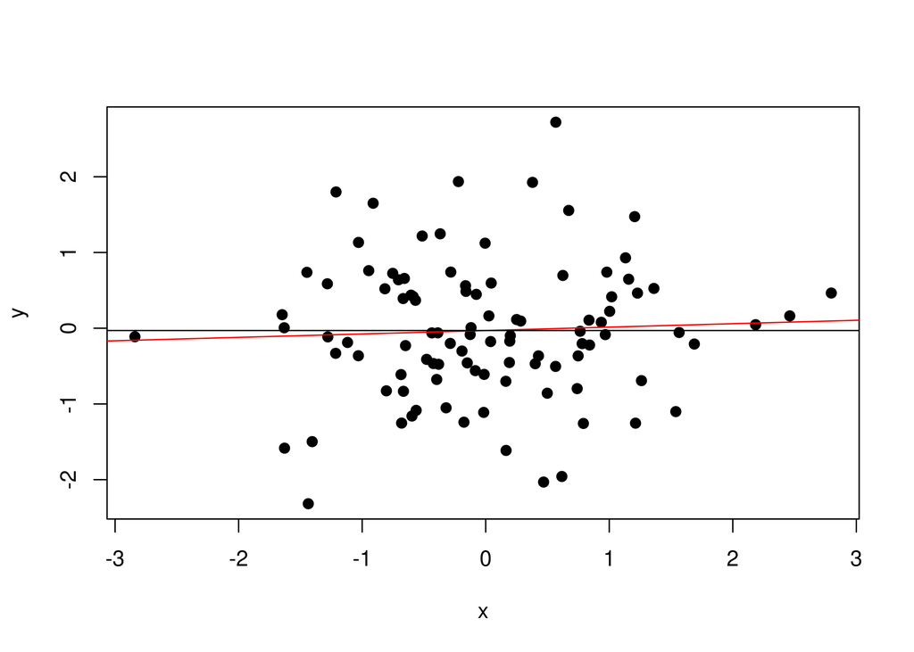

```r
plot(x, y, pch = 19)
abline(lm(y ~ x), col = "red")
abline(h = mean(y))
```

In rosso vediamo la retta di regressione e in nero la media di y. E’ chiaro che le due rette non sono molto diverse suggerendo che la relazione con x non ci dia molta più informazione che la sola media di y.

In termini di modello:

```r
fit <- lm(y ~ x) # modello con x
fit0 <- lm(y ~ 1) # modello con sola intercetta (mean(y))
fit
```

```
##
## Call:
## lm(formula = y ~ x)
##
## Coefficients:
## (Intercept)            x
##    -0.03044      0.04510
```

```r
fit0
```

```
##
## Call:
## lm(formula = y ~ 1)
##
## Coefficients:
## (Intercept)
##    -0.03038
```

## Quanti Parametri?

Il numero dei parametri dipende da:

- il tipo di predittori (numerici o categoriali)
- il tipo di modello (regressione semplice, multipla, multilivello)

Nel caso di una regressione lineare multipla con predittori numerici:

- Intercetta
- 1 parametro per ogni predittore numerico nella formula
- Errore standard dei residui

Nel caso di un modello `y ~ x1 + x2 + x3` abbiamo quindi 5 parametri stimati. Chiaramente nel caso di interazioni, ogni interazione aggiunge un parametro stimato.

Nel caso di una regressione lineare multipla con predittori categoriali:

- Intercetta
- $k - 1$ parametri dove $k$ è il numero di modalità della variabile categoriale
- Errore standard dei residui

Nel caso di un modello `y ~ x1` dove `x1` è un fattore a 2 livelli abbiamo 3 parametri stimati.

## Interpretazione Parametri

L’aspetto più critico della regressione è l’intepretazione dei parametri. Questa permette di leggere chiaramente l’output del nostro modello. Possiamo individuare alcune regole generali:

- `intercetta` = valore di y quando i valori dei predittori (x) sono a 0

L’intepretazione dei parametri nella regressione dipende da:

- tipo di variabili indipendenti (categoriali, numeriche)
- nel caso di variabili categoriali, il tipo di contrasti[^1] utilizzati.

Nel caso di variabili numeriche, il coefficiente di regressione indica l’aumento in `y` quando aumentiamo di 1 unità in `x`. Chiaramente questo dipende dalla scala sia di `y` che di `x`. Ad esempio, se abbiamo 2 questionari di Ansia e Depressione dove il nostro modello `ansia ~ depressione`, per l’aumento di 1 nei punteggi di `depressione` abbiamo un certo aumento di `ansia` (il coefficiente stimato)

Quando abbiamo più predittori, il coefficente viene intepretato come incremento di `y` per incremento unitario di `xi`, tenendo fissi gli altri predittori.

Nel caso di variabili categoriali, il tutto è meno intuitivo. R di default utilizza il dummy coding (o treatment coding). Sostanzialmente per una variabile categoriale a $k$ livelli, vengono create $k - 1$ variabili numeriche binarie (0-1). Questo si può vedere usando il comando `model.matrix()` mostra quello che accade dentro al modello lineare:

```r
x1 <- rep(c("a", "b", "c", "d"), each = 25)
fitc <- lm(y ~ x1)
mm <- data.frame(model.matrix(fitc))
cbind(mm, x1)
```

```
##     X.Intercept. x1b x1c x1d x1
## 1              1   0   0   0  a
## 2              1   0   0   0  a
## 3              1   0   0   0  a
## 4              1   0   0   0  a
## 5              1   0   0   0  a
## 6              1   0   0   0  a
## 7              1   0   0   0  a
## 8              1   0   0   0  a
## 9              1   0   0   0  a
## 10             1   0   0   0  a
## 11             1   0   0   0  a
## 12             1   0   0   0  a
## 13             1   0   0   0  a
## 14             1   0   0   0  a
```

[output cut: 86 more lines]

In questo modo il primo livello viene preso come riferimento (**a**, `intercetta`) e tutti i parametri corrispondono alla differenza tra il livello 2 vs 1, 3 vs 1 etc.

I test sui coefficienti che viene visualizzato con `summary()` non sono altro che `t-test` dove $H_0: \beta_i = 0$ e $H_1: \beta_i \neq 0$.

Per disegni più complessi (più predittori, interazioni, etc.) la situazione è più complessa ma il principio è lo stesso.

Alcuni consigli e considerazioni:

- in generale, modelli migliori non sono sempre modelli più complessi. Una parte importante dell’analisi è intepretare in modo chiaro i parametri, cosa che viene molto difficile quando il modello è troppo complesso.
- non sempre i coefficienti hanno un significato funzionale diretto. Ad esempio, l’intercetta non è sempre interessante da un punto di vista intepretativo. La cosa miglio è sempre guardare anche gli effetti `anova(fit)` ma sopratutto rappresentare graficamente il modello.
- Se vogliamo comunque intepretare i parametri, sopratutto quelli categoriali, un buon esercizio è quello di calcolare le medie per ogni condizione del nostro dataset, e cercare di confrontare i parametri con le differenze che calcoliamo a mano.

```r
dat <- data.frame(y, x1)
head(dat)
```

```
##            y x1
## 1 -1.1116498  a
## 2  0.2230306  a
## 3 -1.6138455  a
## 4  1.4734500  a
## 5 -1.4977817  a
## 6  0.6968586  a
```

```r
aggregate(y ~ x1, data = dat, FUN = mean)
```

```
##   x1            y
## 1  a  0.002050717
## 2  b -0.153892314
## 3  c  0.033517772
## 4  d -0.003177400
```

Ora confrontiamo questo con il modello:

```r
fitc
```

```
##
## Call:
## lm(formula = y ~ x1)
##
## Coefficients:
## (Intercept)          x1b          x1c          x1d
##    0.002051    -0.155943     0.031467    -0.005228
```

L’intercetta dovrebbe essere la media di `a`. `x1b` dovrebbe essere la differenza tra `b` e `a` e così via.

## Tutto è una regressione lineare

Un aspetto molto importante da capire è che tutto quello che abbiamo fatto fino ad ora (t-test, anova, etc.) fa parte della famiglia della regressione lineare. In particolare:

- L’`anova` è un tipo di regressione dove i predittori sono solo categoriali. In caso di 1 predittore, i livelli sono > 2.
- Il `t-test` è un tipo di `anova` (e quindi di regressione) dove è presente 1 solo parametro categoriale con 2 livelli.

Creiamo un dataframe per fare un `t-test`:

```r
datt <- data.frame(
    y = rnorm(100),
    x = rep(c("a", "b"), each = 50)
)

head(datt)
```

```
##            y x
## 1  0.5598182 a
## 2  1.1284627 a
## 3  0.4956476 a
## 4  1.8338638 a
## 5 -0.5720865 a
## 6 -0.1801013 a
```

Ora calcoliamo il `t-test` ma facciamo anche una regressione lineare:

```r
t.test(y ~ x, data = datt, var.equal = TRUE)
```

```
##
##  Two Sample t-test
##
## data:  y by x
## t = 1.3733, df = 98, p-value = 0.1728
## alternative hypothesis: true difference in means between group a and group b is not equal to 0
## 95 percent confidence interval:
##  -0.1105808  0.6075860
## sample estimates:
## mean in group a mean in group b
##       0.1123968      -0.1361058
```

```r
summary(lm(y ~ x, data = datt))
```

```
##
## Call:
## lm(formula = y ~ x, data = datt)
##
## Residuals:
##      Min       1Q   Median       3Q      Max
## -2.55759 -0.72695 -0.01232  0.51619  2.50124
##
## Coefficients:
##             Estimate Std. Error t value Pr(>|t|)
## (Intercept)   0.1124     0.1279   0.878    0.382
## xb           -0.2485     0.1809  -1.373    0.173
##
## Residual standard error: 0.9047 on 98 degrees of freedom
## Multiple R-squared:  0.01888,    Adjusted R-squared:  0.008871
## F-statistic: 1.886 on 1 and 98 DF,  p-value: 0.1728
```

In base a quello che abbiamo detto prima, l’intercetta è la media di `y` quando `x` = 0 (ovvero è `a`, il valore di riferimento). `xb` è la differenza tra `b` e `a`. Il test rappresenta il `t-test` sulla differenza tra `b` e `a`. Esattamente quello che fa il comando `t.test()`.

Lo stesso vale per l’`anova`. Creiamo un dataset con `x` > 2 livelli:

```r
dataov <- data.frame(
    y = rnorm(100),
    x = rep(c("a", "b", "c", "d"), each = 25)
)

head(dataov)
```

```
##            y x
## 1 -0.7804166 a
## 2 -0.1206123 a
## 3 -1.0588556 a
## 4  2.0572205 a
## 5  0.1470409 a
## 6 -1.7924565 a
```

Calcoliamo sia l’anova con il comando `aov` che `anova` sul modello fittato:

```r
summary(aov(y ~ x, data = dataov))
```

```
##             Df Sum Sq Mean Sq F value Pr(>F)
## x            3   2.84  0.9467   0.898  0.445
## Residuals   96 101.20  1.0541
```

```r
anova(lm(y ~ x, data = dataov))
```

```
## Analysis of Variance Table
##
## Response: y
##           Df Sum Sq Mean Sq F value Pr(>F)
## x          3   2.84 0.94672  0.8981 0.4452
## Residuals 96 101.19 1.05412
```

Come vedete i risultati sono identici.

Per approfondire il fatto che tutto alla fine è una regressione questo è un ottimo riferimento https://lindeloev.github.io/tests-as-linear/.

[^1]: Questo è un argomento abbastanza complesso e può generare molta confusione. L’idea generale è che per trattare variabili categoriali R ricodifica in variabili numeriche i nostri predittori. Questa ricodifica non è sempre uguale (e.g., dummy coding) diversi modi di impostare i contrasti cambiano il modo di intepretare i parametri. Il modello in termini di $R^2$ e altri parametri rimane sempre uguale